# Essential Tools for Writing a Paper

Bibliography Manager, Word Processing

Bogdan G. Popescu

bogdan.popescu@johncabot.edu

John Cabot University

## Your Workspace

Any project needs to start with a clean workspace

You need to have dedicated folders for:

- data
- literature
- paper
- presentation

Having a clean workspace will give you clarity.

As we progress throughout the course, we will keep adding files and data to the folder

## Your Workspace

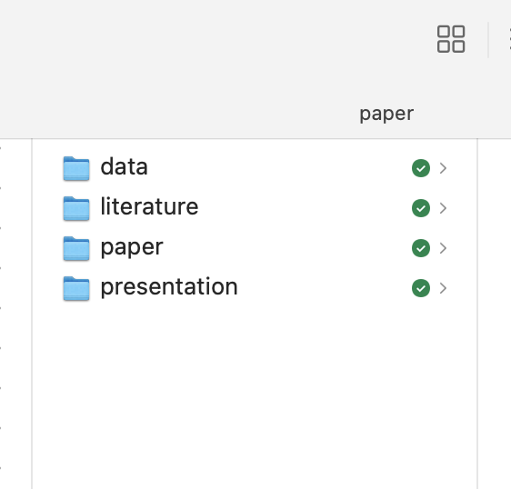

## Reference Software

### JabRef

This is reference manager software.

It is freely available

It saves the literature in a table-like format.

It later allows to format citations in the desired format (e.g. APA)

Only commands like “cite” are necessary.

## Reference Software: JabRef

### Downloading

[figure not shown]

## Reference Software: JabRef

### Downloading

[figure not shown]

## Reference Software: JabRef

### Downloading

[figure not shown]

## Reference Software: JabRef

### Downloading

[figure not shown]

## Reference Software: JabRef

### Interface

[figure not shown]

## Reference Software: JabRef

### Interface

[figure not shown]

## Reference Software: JabRef

### Interface

[figure not shown]

## Reference Software: JabRef

### Article

[figure not shown]

## Reference Software: JabRef

### Article

[figure not shown]

## Reference Software: JabRef

### Article

[figure not shown]

## Reference Software: JabRef

### Article

[figure not shown]

## Reference Software: JabRef

### Article

Note the citation key

I typically choose “NameYear” as convention. It’s a good way to remember whom you cite.

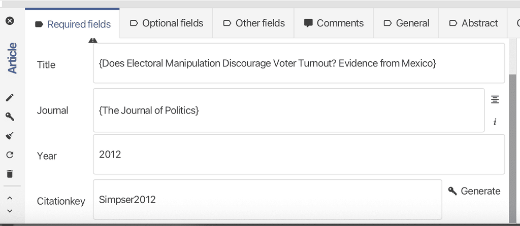

## Reference Software: JabRef

### Article

[figure not shown]

## Reference Software: JabRef

### Article

[figure not shown]

## Reference Software: JabRef

### Article

Note that if you have more than one author you need to write them under the author section in JabRef:

“Acemoglu, Daron, and Robinson, James, and Johnson, Simon”

## Reference Software: JabRef

### Book

[figure not shown]

## Reference Software: JabRef

### Book

[figure not shown]

## Reference Software: JabRef

### Book

[figure not shown]

## Reference Software: JabRef

### Book

[figure not shown]

## Reference Software: JabRef

### Book

[figure not shown]

## Reference Software: JabRef

### Book

[figure not shown]

## Reference Software: JabRef

### Chapter in Edited Volume

[figure not shown]

## Reference Software: JabRef

### Chapter in Edited Volume

[figure not shown]

## Reference Software: JabRef

### Chapter in Edited Volume

[figure not shown]

## Reference Software: JabRef

### Chapter in Edited Volume

[figure not shown]

## Reference Software: JabRef

### Chapter in Edited Volume

[figure not shown]

## Reference Software: JabRef

### Chapter in Edited Volume

[figure not shown]

## Reference Software: JabRef

### Saving the Library

[figure not shown]

## Reference Software: JabRef

### Saving the Library

[figure not shown]

## Reference Software: JabRef

### Saving the Library

[figure not shown]

## Reference Software: JabRef

### Saving the Library

[figure not shown]

## Citations

### American Psychological Association (APA) Style

This is the recommended way to cite:

**Book**

Acemoglu, Daron, and James Robinson. 2012. Why Nations Fail: The Origins of Power, Prosperity and Poverty. New York: Crown.

**Article**

Simpser, Alberto. 2012. “Does Electoral Manipulation Discourage Voter Turnout? Evidence from Mexico.” The Journal of Politics 74: 782–95.

**Chapter in Edited Volume**

Tiliouine, Habib, Renima Ahmed, and Richard J. Estes. 2016. “The Changing Map of the Islamic World: From the Abbasid Era to the Ottoman Empire of the Twentieth Century.” In The State of Social Progress of Islamic Societies, edited by Habib Tiliouine and Richard J. Estes, 53–68. Routledge.

**Once you use JabRef, you will no longer have to worry about citation styles !!!**

## Quarto

### What is Quarto?

Quarto - open-source publishing system designed for creating dynamic, reproducible documents, including reports, presentations, and websites.

It supports multiple formats like HTML, PDF, Word, and slides.

**Why Use Quarto?**

- Integrates well with R, Python, and Julia.
- Enables embedding of code chunks directly in documents for dynamic content generation.
- Facilitates reproducibility by linking code and results seamlessly.

## Quarto

### The Template

We want to obtain a PDF that is commonly used in academia

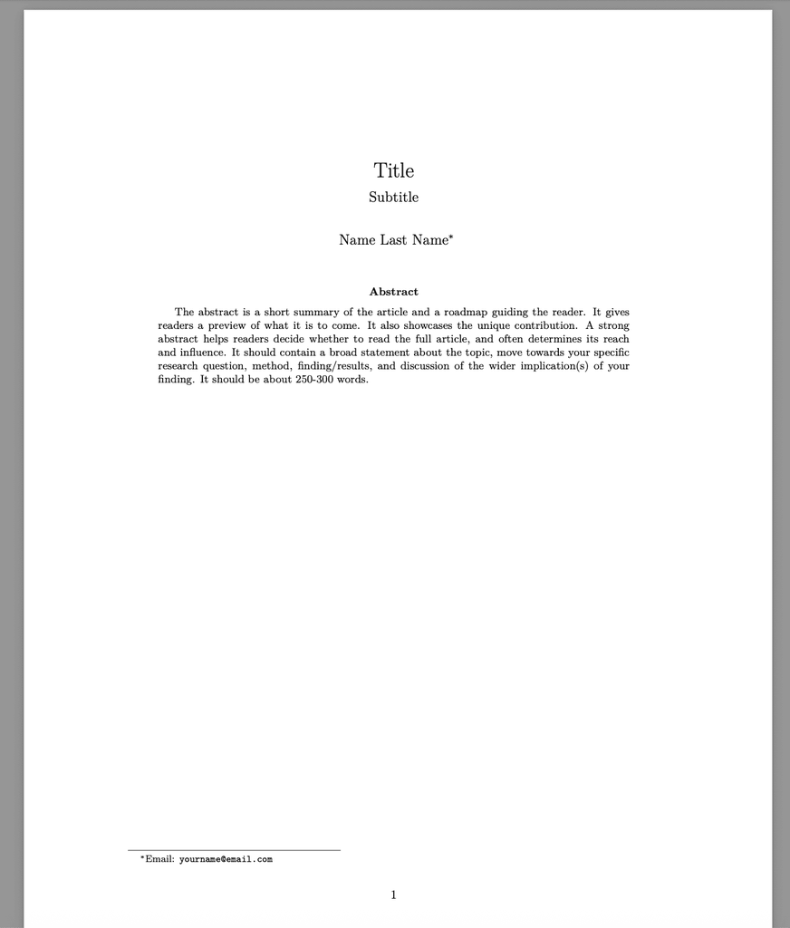